# Reproducible Research project 1

Xue Zhang

2019/1/28

## Loading and preprocessing the data

Show any code that is needed to

1.Load the data (i.e. read.csv())

```r
setwd("E:/r/5.reproducible/project1")
Sys.setlocale("LC_TIME", "English")
```

```
## [1] "English_United States.1252"
```

```r
data0 <- read.csv("activity.csv",colClasses = "character")
```

2.Process/transform the data (if necessary) into a format suitable for your analysis

```r
data0$steps <- as.numeric(data0$steps)
data0$date <- as.Date(data0$date,"%Y-%m-%d")
data0$interval <- as.numeric(data0$interval)
```

## What is mean total number of steps taken per day?

For this part of the assignment, you can ignore the missing values in the dataset.

```r
data <- data0[!is.na(data0[,1]),]
stepsperday <- tapply(data$steps, data$date, sum)
```

1.Make a histogram of the total number of steps taken each day

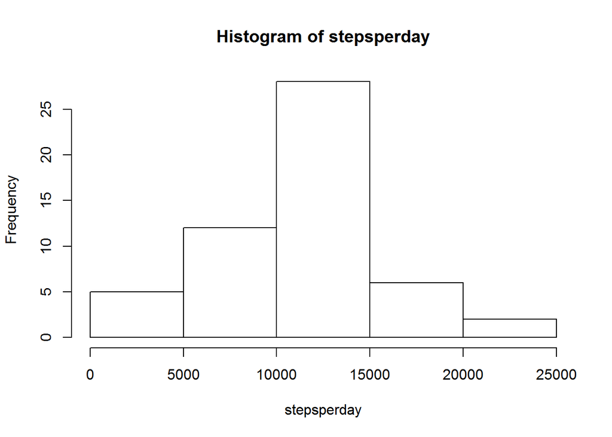

```r
hist(stepsperday)
```

2.Calculate and report the mean and median total number of steps taken per day

```r
mean(stepsperday)
```

```
## [1] 10766.19
```

```r
median(stepsperday)
```

```
## [1] 10765
```

## What is the average daily activity pattern?

1.Make a time series plot (i.e. type = “l”) of the 5-minute interval (x-axis) and the average number of steps taken, averaged across all days (y-axis)

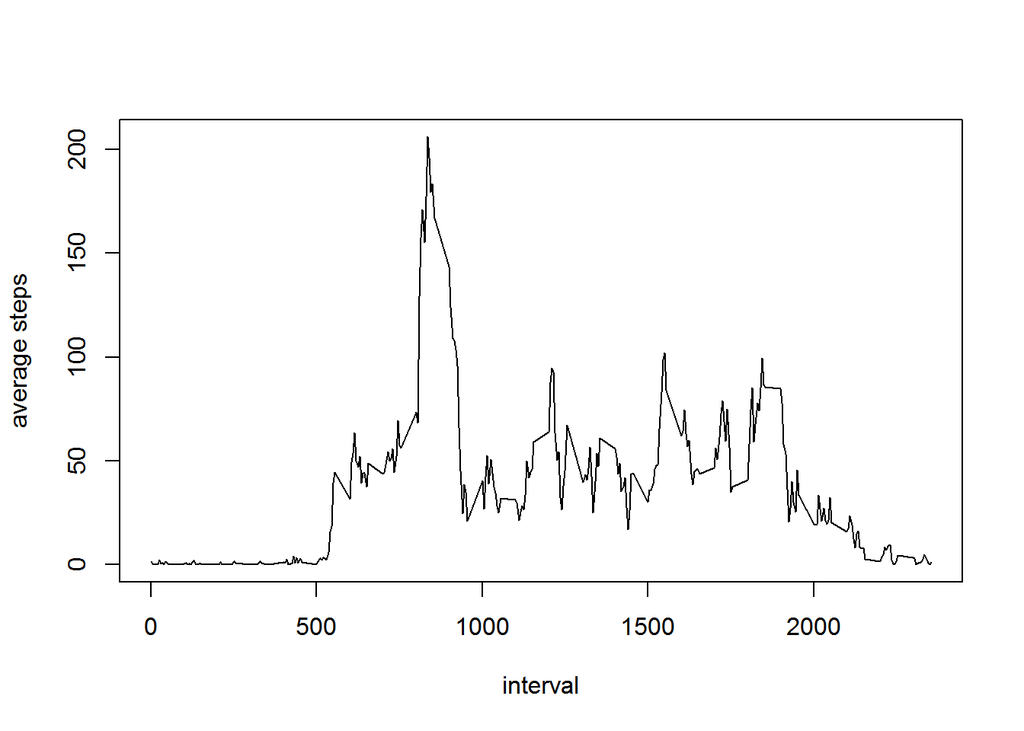

```r
steps_interval <- aggregate(data$steps,by=list(data$interval),mean)
names(steps_interval) <- c("interval","steps")
plot(steps_interval$interval,steps_interval$steps,type="l",ylab = "average steps",xlab = "interval")
```

2.Which 5-minute interval, on average across all the days in the dataset, contains the maximum number of steps?

```r
steps_interval[which.max(steps_interval$steps),]
```

```
##     interval    steps
## 104      835 206.1698
```

## Imputing missing values

Note that there are a number of days/intervals where there are missing values (coded as NA). The presence of missing days may introduce bias into some calculations or summaries of the data.

1.Calculate and report the total number of missing values in the dataset (i.e. the total number of rows with NAs)

```r
sum(!complete.cases(data0))
```

```
## [1] 2304
```

```r
colnames(steps_interval) <- c("interval","average steps")
a <- merge(data0,steps_interval,by="interval",all = TRUE)
if(is.na(data0$steps)){
  data0[,1] <-a[,4]
}
```

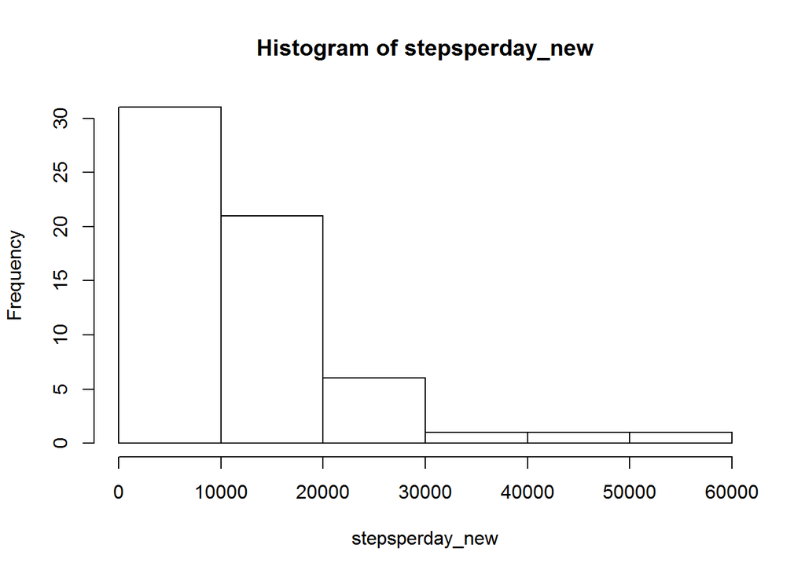

```r
stepsperday_new <- tapply(data0$steps, data0$date, sum)
hist(stepsperday_new)
```

## Are there differences in activity patterns between weekdays and weekends?

For this part the weekdays() function may be of some help here. Use the dataset with the filled-in missing values for this part.

1.Create a new factor variable in the dataset with two levels – “weekday” and “weekend” indicating whether a given date is a weekday or weekend day.

```r
data0$weekdays <- weekdays(data0$date,abbreviate=TRUE)
a <-ifelse(data0$weekdays%in%c("Mon","Tue","Wed","Thu","Fri"),"weekday","weekend")
data0$week <- a
```

2.Make a panel plot containing a time series plot (i.e. type = “l”) of the 5-minute interval (x-axis) and the average number of steps taken, averaged across all weekday days or weekend days (y-axis).

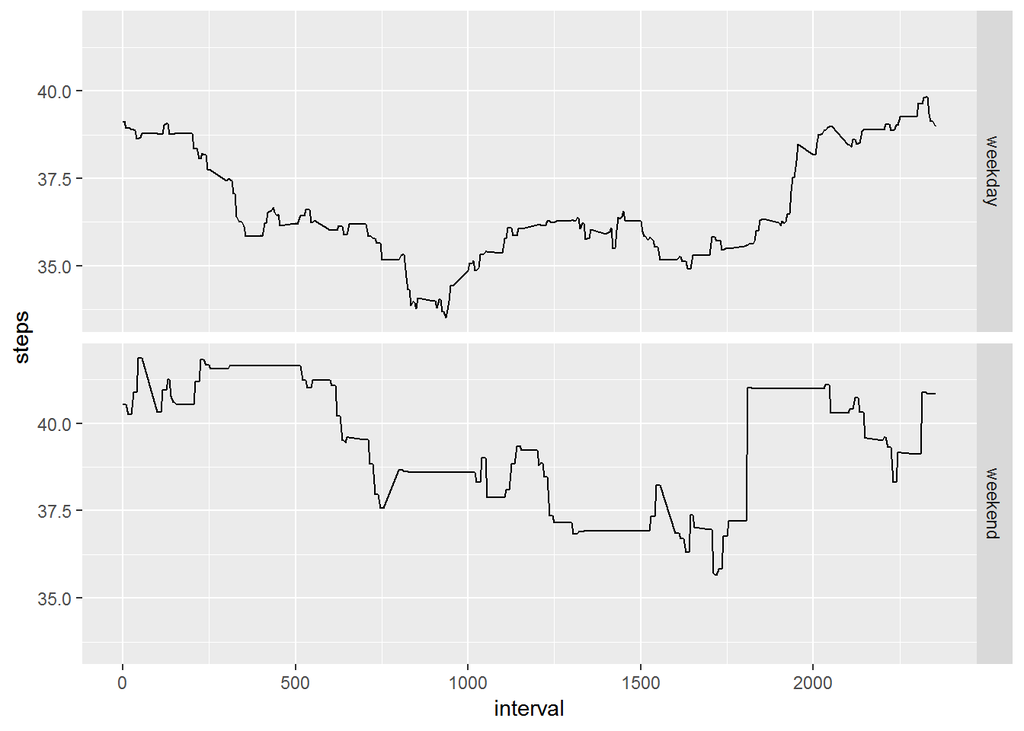

```r
data_weekday <- data0[which(data0$week == "weekday"),]
data_weekend <- data0[which(data0$week == "weekend"),]
steps_weekday <- aggregate(data_weekday$steps,by=list(data_weekday$interval),mean)

steps_weekday$group <- "weekday"
steps_weekend <- aggregate(data_weekend$steps,by=list(data_weekend$interval),mean)

steps_weekend$group <- "weekend"
data_final <- rbind(steps_weekday,steps_weekend)
names(data_final) <- c("interval","steps","group")
library(ggplot2)
ggplot(data_final,aes(x=interval,y=steps))+geom_line()+facet_grid (group~.)
```